# ST1131 Introduction to Statistics and Statistical Computing

## Tutorial 1

```python
# Verify the notebook is using venv-st1131
# You should see either \venv-st1131\Scripts\python.exe or /venv-st1131/bin/python
import sys
from pathlib import Path
print(Path(*Path(sys.executable).parts[-3:]))
```

```
venv-st1131\Scripts\python.exe
```

```python
# Verify required packages
import numpy as np
import pandas as pd
import matplotlib.pyplot as plt

print("Everything works!")
```

```
Everything works!
```

### Question 1

Consider the following data on diastolic blood pressure (measured in mm Hg) for 9 patients. Answer questions below and leave your final answers to 2 decimal places.

| Patient | 1 | 2 | 3 | 4 | 5 | 6 | 7 | 8 | 9 |
| --- | --- | --- | --- | --- | --- | --- | --- | --- | --- |
| Blood pressure | 96 | 119 | 119 | 108 | 126 | 128 | 110 | 105 | 94 |

(a) Input the data into Python and sort it. Manually find the median of the dataset, then use Python to get the median directly. Are the results the same?

Create a list named `bp` which has the 9 values as given:

```python
bp = [96, 119, 119, 108, 126, 128, 110, 105, 94]

bp_sorted = sorted(bp)
print(bp_sorted)
```

```
[94, 96, 105, 108, 110, 119, 119, 126, 128]
```

Since there is an odd number of values, the median is the $\frac{n+1}{2}$-th term after sorting, which is the 5th term. Hence, the median is 110.

```python
import numpy as np

median = np.median(bp)
print(round(median, 2))
```

```
110.0
```

Both the manual calculation and Python give a median of 110.00 mm Hg. This makes sense as with an odd number of observations, the median is simply the middle value once the data is sorted, which is exactly what `np.median()` computes under the hood.

(b) Determine the mean, variance and standard deviation of the dataset.

You can use either `numpy` or `pandas`, but be careful of what each default function does for variance and standard deviation.

```python
import numpy as np
import pandas as pd

bp = [96, 119, 119, 108, 126, 128, 110, 105, 94]

mean = np.mean(bp)
variance = np.var(bp, ddof=1) #ddof=1, sample variance
sd = np.std(bp, ddof=1) #ddof=1, sample standard deviation

#You can use pandas instead, but the list has to be changed to a Series first
bp_df = pd.Series(bp)
mean_df = bp_df.mean()
variance_df = bp_df.var() #sample variance by default
sd_df = bp_df.std() #sample standard deviation by default

print("numpy")
print(round(mean, 2))
print(round(variance, 2))
print(round(sd, 2))
print()
print("pandas")
print(round(mean_df, 2))
print(round(variance_df, 2))
print(round(sd_df, 2))
```

```
numpy
111.67
149.75
12.24

pandas
111.67
149.75
12.24
```

(c) Suppose we are now told that the measurement machine was not zero-ed, and that everyone's reading should be **reduced by 10 mm Hg**. What is the new mean and variance of the dataset? Does the mean change? Does the variance change?

Conceptually, if value is reduced by a constant $c$, which is 10 here, then for the new dataset will have the mean reduced by the same constant. Variance should remain unchanged because variance measures spread around the mean, not the mean itself. Shifting every value by the same constant shifts the mean by that constant too. So each deviation stays exactly the same after the shift, since both the data and the mean move by the same amount. No spread is added or removed, the whole dataset slides together.

```python
bp_adjusted = [x - 10 for x in bp] #using a for loop to change every element

#You can use a np array instead of a list to make it simpler
bp_array = np.array(bp)
bp_adjusted = bp_array - 10

new_mean = np.mean(bp_adjusted)
new_variance = np.var(bp_adjusted, ddof=1)

print(round(new_mean, 2))
print(round(new_variance, 2))
```

```
101.67
149.75
```

The changes in mean and variance is in line with what we mentioned earlier.

(d) Create a boxplot of the new data and label the title and $y$-axis of your boxplot as accurately as possible.

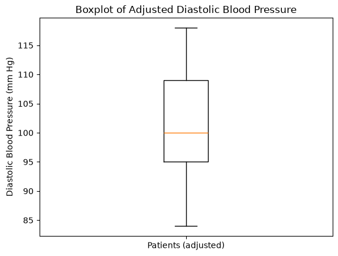

```python
import matplotlib.pyplot as plt

plt.boxplot(bp_adjusted)
plt.title("Boxplot of Adjusted Diastolic Blood Pressure")
plt.ylabel("Diastolic Blood Pressure (mm Hg)")
plt.xticks([1], ["Patients (adjusted)"])
plt.show()
```

(e) Create a histogram of the new data (using probability) and label its $x$-axis.

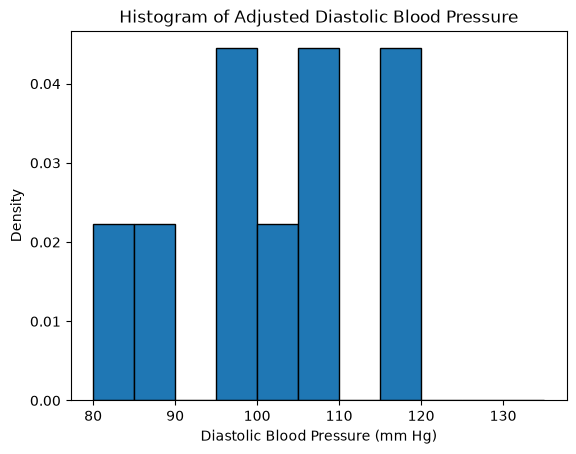

```python
bin_edges = np.arange(80, 140, 5) #optional to change where the bins are, (start, end which is excluded, size)
plt.hist(bp_adjusted, bins=bin_edges, density=True, edgecolor="black")
#plt.hist(bp_adjusted, density=True, edgecolor="black") #use this if no bin customisations
plt.title("Histogram of Adjusted Diastolic Blood Pressure")
plt.xlabel("Diastolic Blood Pressure (mm Hg)")
plt.ylabel("Density")
plt.show()
```

### Question 2

For each of the following experiments, identify the variable(s), the data type of each variable, and the sample size.

(a) For each of 10 beetles, a biologist counted the number of times the beetle fed on a disease-resistant plant during a 4-hour period.

The only one quantitative discrete variable recorded is the count. The sample size is 10.

(b) In a nutritional study, 40 healthy males were measured for height and weight as well as the weight of their food intake over a 24-hour period.

There are 3 variables recorded: height (quantitative continuous), weight (quantitative continuous) and weight of food intake (quantitative continuous). The sample size is 40.

(c) The birth weight, number of siblings, mother's race, and age were recorded for each of 85 babies born at NUH.

There are 4 variables recorded: birth weight (quantitative continuous), number of siblings (quantitative discrete), race (categorical nominal) and age (quantitative continuous). The sample size is 85.

### Question 3

The histograms and boxplots of three datasets are plotted in Figure 1. Each dataset consists of 1000 points. Match the following phrases to each of the datasets: "symmetric and bimodal", "symmetric" and "skewed right".

(Do note that if you want to be able to export this to HTML, you need to create a sister folder, `images`, together with `src` and `data` previously, and insert all images used in this file from Canvas into that folder before exporting. If you do not need the images, do delete the short code below that imported the image. This will be the case for any images that are imported instead of created here.)

[figure not shown]

*Figure 1*

Dataset 1 is symmetric  
Dataset 2 is skewed right  
Dataset 3 is symmetric and bimodal.

### Question 4

The histograms and boxplots of three datasets are plotted below, in Figure 2. However, the order of plots in top and bottom are not the same! Match the histogram with the correct boxplot.

[figure not shown]

*Figure 2*

Looking at the range of values ($x$-axis of the histograms, $y$-axis of the box plots), we have:  
Histogram 1 matches with Boxplot 3,  
Histogram 2 matches with Boxplot 1,  
Histogram 3 matches with Boxplot 2.

### Question 5

The marks of a final exam of a course are recorded in the file `final_marks.csv`.

(a) Import the data into Python. Rename the second column of the data as `mark`.

There are two easy ways to do that. If you know the original column name, you can use `.rename()` to change from old to new. If you do not, but you know the column index number, you can use `.column.values[index]` to assign a new name.

```python
data = pd.read_csv("../data/final_marks.csv")
print(data.head())
print()
data = data.rename(columns={"x": "mark"})
#data.columns.values[1] = "mark"
print(data.head())
```

```
   Unnamed: 0     x
0           1  34.0
1           2  33.0
2           3  42.0
3           4  42.0
4           5  17.0

   Unnamed: 0  mark
0           1  34.0
1           2  33.0
2           3  42.0
3           4  42.0
4           5  17.0
```

(b) How may student took the exam? Derive some summaries of the final mark (mean, median, variance, IQR and range).

```python
n_students = data["mark"].count()   # count() excludes NaN, in case of missing marks
print(f"There are {n_students} students who took the exam.")

mean = data["mark"].mean()
median = data["mark"].median()
variance = data["mark"].var() #pandas defaults to sample variance
q1 = data["mark"].quantile(0.25)
q3 = data["mark"].quantile(0.75)
iqr = q3 - q1
data_range = data["mark"].max() - data["mark"].min()

print(f"Mean: {mean:.2f}")
print(f"Median: {median:.2f}")
print(f"Variance: {variance:.2f}")
print(f"IQR: {iqr:.2f}")
print(f"Range: {data_range:.2f}")
```

```
There are 98 students who took the exam.
Mean: 31.33
Median: 33.00
Variance: 98.74
IQR: 11.75
Range: 44.00
```

(c) Create a boxplot of the final marks. Does the sample has any outlier? If yes, identify that outlier.

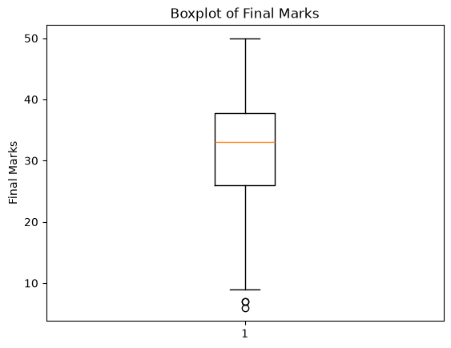

```python
plt.boxplot(data["mark"])
plt.title("Boxplot of Final Marks")
plt.ylabel("Final Marks")
plt.show()
```

There are at least 2 visible outliers. To identify them, we need to find the lower bound first. The upper bound is not needed as there are no visible outliers in the upper side, but let's just include it.

```python
lower_bound = q1 - 1.5 * iqr
upper_bound = q3 + 1.5 * iqr
print(f"Any values smaller than {lower_bound} or higher than {upper_bound} are considered outliers.")

outliers = data[(data["mark"] < lower_bound) | (data["mark"] > upper_bound)]
print(outliers)
```

```
Any values smaller than 8.375 or higher than 55.375 are considered outliers.
    Unnamed: 0  mark
30          31   7.0
43          44   7.0
78          79   6.0
```

The results show us that there are 3 outliers, 2 valued at 7 (ID 31 and 44), and 1 valued at 6 (ID 79).

(d) Create a histogram of the final marks (by probability) and label its $x$-axis. By default, how many bins does the created histogram have? Try changing the number of bins.

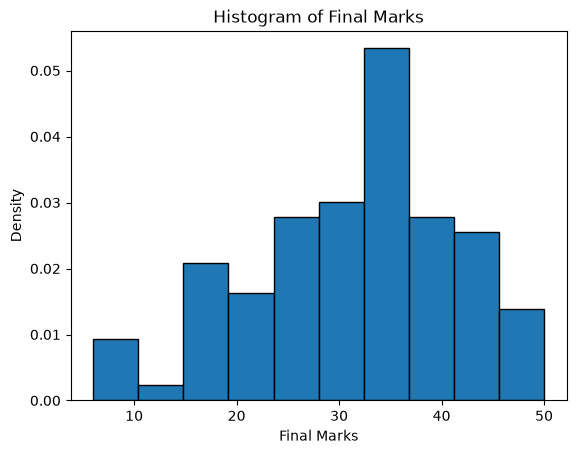

```python
plt.hist(data["mark"], density=True, edgecolor="black")
plt.title("Histogram of Final Marks")
plt.xlabel("Final Marks")
plt.ylabel("Density")
plt.show()
```

By default, `matplotlib` plots 10 bins. There are 2 easy ways to customise the bins using an optional argument called `bin`. The first is to say the number of bins you want. The second is to provide the exact bins you want.

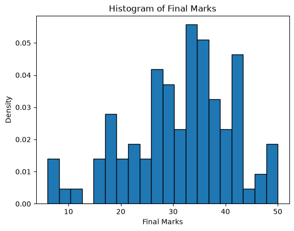

```python
#First way
plt.hist(data["mark"], bins=20, density=True, edgecolor="black") #20 bins
plt.title("Histogram of Final Marks")
plt.xlabel("Final Marks")
plt.ylabel("Density")
plt.show()
```

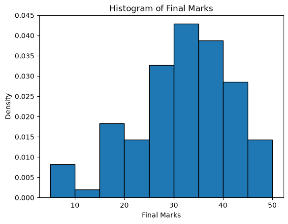

```python
#Second way
bin_edges = np.arange(5, 55, 5) #explicitly decice what the bins are, (start, end which is excluded, size)
plt.hist(data["mark"], bins=bin_edges, density=True, edgecolor="black")
plt.title("Histogram of Final Marks")
plt.xlabel("Final Marks")
plt.ylabel("Density")
plt.show()
```